# Tugas Pertemuan 7

Raziqizzan Putrandi - G1401211040

### Library

```r
library("forecast")
```

```r
library("graphics")
library("TTR")
library("TSA")
library(dplyr)
library(forecast)
library(lmtest)
library(orcutt)
library(HoRM)
library(corrplot)
library(dLagM)
library(dynlm)
library(MLmetrics)
library(ggplot2)
library(tsibble)
library(tseries)
library(MASS)
library(aTSA)
```

# Input data

```r
data7 <- read.csv("https://raw.githubusercontent.com/Raziqizzan03/MPDW/main/Pertemuan%207/data%20suhu%20mekkah.csv")
data7
```

```
##     periode suhu.mekkah
## 1         1       24.10
## 2         2       25.12
## 3         3       28.51
## 4         4       32.99
## 5         5       36.16
## 6         6       38.19
## 7         7       37.94
## 8         8       38.61
## 9         9       36.91
## 10       10       33.96
## 11       11       28.77
## 12       12       24.22
## 13       13       21.07
## 14       14       24.29
```

[output cut: 130 more lines]

### Ubah data menjadi time series

```r
data7.ts <- ts(data7$suhu.mekkah)
```

### Membagi data menjadi data latih (80%) dan data uji (20%) dan jadikan time series

```r
dt7.latih <- data7[1:115,2]
dt7.uji <- data7[116:144,2]
dt7.latih.ts <- ts(dt7.latih, frequency = 12)
dt7.uji.ts <- ts(dt7.uji, frequency = 12)
```

# Eksplorasi data

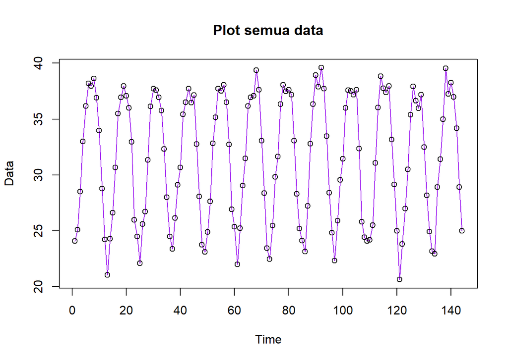

```r
# data full
ts.plot(data7.ts, col="purple",main="Plot semua data", type="o",xlab="Time",ylab="Data")
points(data7.ts)
```

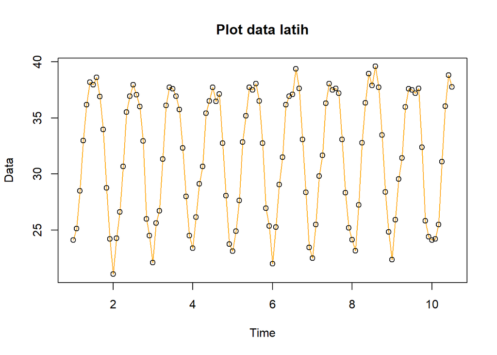

```r
# data latih
ts.plot(dt7.latih.ts, col="orange",main="Plot data latih", type="o",xlab="Time",ylab="Data")
points(dt7.latih.ts)
```

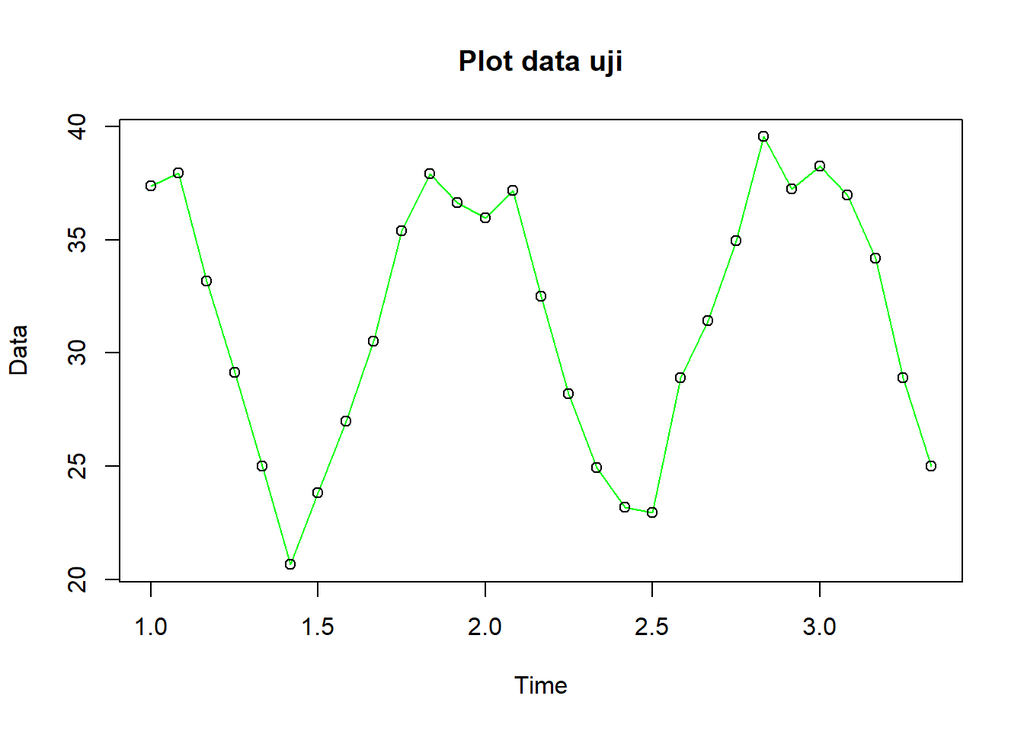

```r
# data uji
ts.plot(dt7.uji.ts, col="green",main="Plot data uji", type="o",xlab="Time",ylab="Data")
points(dt7.uji.ts)
```

dapat dilihat bahwwa data deret waktu pada suhu mekkah membentuk pola aditif musiman tanpa trend

# CEK Stasioner

### Plot acf

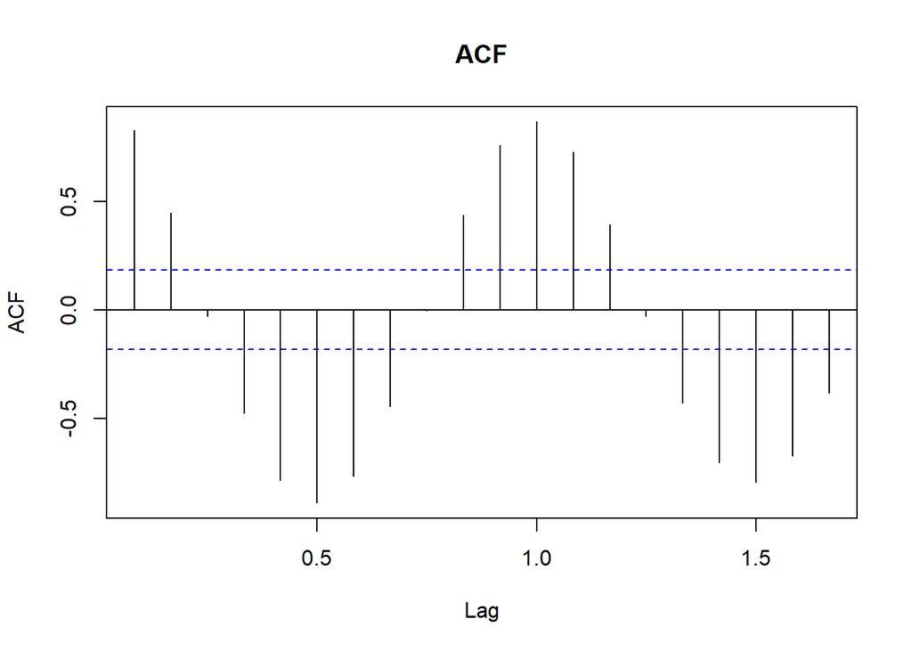

```r
acf(dt7.latih.ts, main="ACF", lag.max=20)
```

Berdasarkan plot ACF, terlihat bahwa plot ACF pada data tersebut cenderung *tails off* dan membentuk gelombang sinus. menandakan bahwa data tersebut stasioner dalam rataan

### Uji ADF

```r
tseries::adf.test(dt7.latih.ts)
```

```
##
##  Augmented Dickey-Fuller Test
##
## data:  dt7.latih.ts
## Dickey-Fuller = -10.676, Lag order = 4, p-value = 0.01
## alternative hypothesis: stationary
```

$H_0$ : Data tidak stasioner dalam rataan

$H_1$ : Data stasioner dalam rataan

Berdasarkan uji ADF tersebut, didapat *p-value* sebesar 0.01 yang lebih kecil dari taraf nyata 5% sehingga tolak $H_0$ dan menandakan bahwa data stasioner dalam rataan. Hal ini sesuai dengan hasil eksplorasi menggunakan plot time series dan plot ACF.

### Plot Box-Cox

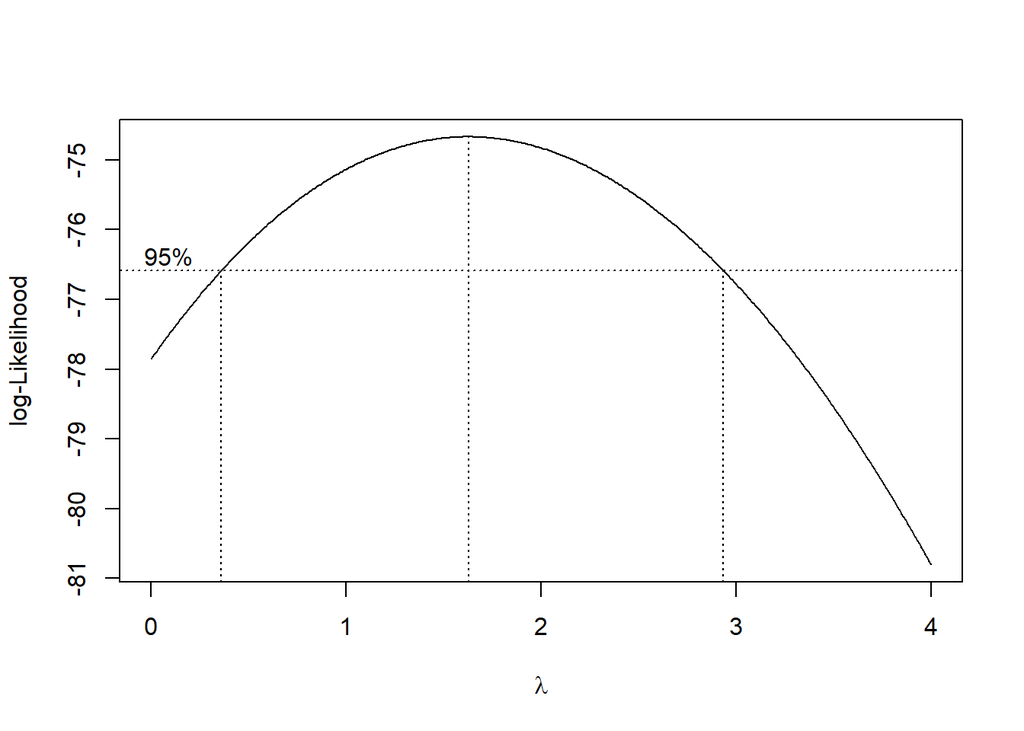

```r
index <- seq(1:115)
bc = boxcox(dt7.latih.ts~index, lambda = seq(0,4,by=0.01))
```

```r
#Nilai Rounded Lambda
lambda <- bc$x[which.max(bc$y)]
lambda
```

```
## [1] 1.63
```

```r
#SK
bc$x[bc$y > max(bc$y) - 1/2 * qchisq(.95,1)]
```

```
##   [1] 0.36 0.37 0.38 0.39 0.40 0.41 0.42 0.43 0.44 0.45 0.46 0.47 0.48 0.49 0.50
##  [16] 0.51 0.52 0.53 0.54 0.55 0.56 0.57 0.58 0.59 0.60 0.61 0.62 0.63 0.64 0.65
##  [31] 0.66 0.67 0.68 0.69 0.70 0.71 0.72 0.73 0.74 0.75 0.76 0.77 0.78 0.79 0.80
##  [46] 0.81 0.82 0.83 0.84 0.85 0.86 0.87 0.88 0.89 0.90 0.91 0.92 0.93 0.94 0.95
##  [61] 0.96 0.97 0.98 0.99 1.00 1.01 1.02 1.03 1.04 1.05 1.06 1.07 1.08 1.09 1.10
##  [76] 1.11 1.12 1.13 1.14 1.15 1.16 1.17 1.18 1.19 1.20 1.21 1.22 1.23 1.24 1.25
##  [91] 1.26 1.27 1.28 1.29 1.30 1.31 1.32 1.33 1.34 1.35 1.36 1.37 1.38 1.39 1.40
## [106] 1.41 1.42 1.43 1.44 1.45 1.46 1.47 1.48 1.49 1.50 1.51 1.52 1.53 1.54 1.55
## [121] 1.56 1.57 1.58 1.59 1.60 1.61 1.62 1.63 1.64 1.65 1.66 1.67 1.68 1.69 1.70
## [136] 1.71 1.72 1.73 1.74 1.75 1.76 1.77 1.78 1.79 1.80 1.81 1.82 1.83 1.84 1.85
## [151] 1.86 1.87 1.88 1.89 1.90 1.91 1.92 1.93 1.94 1.95 1.96 1.97 1.98 1.99 2.00
## [166] 2.01 2.02 2.03 2.04 2.05 2.06 2.07 2.08 2.09 2.10 2.11 2.12 2.13 2.14 2.15
## [181] 2.16 2.17 2.18 2.19 2.20 2.21 2.22 2.23 2.24 2.25 2.26 2.27 2.28 2.29 2.30
## [196] 2.31 2.32 2.33 2.34 2.35 2.36 2.37 2.38 2.39 2.40 2.41 2.42 2.43 2.44 2.45
## [211] 2.46 2.47 2.48 2.49 2.50 2.51 2.52 2.53 2.54 2.55 2.56 2.57 2.58 2.59 2.60
## [226] 2.61 2.62 2.63 2.64 2.65 2.66 2.67 2.68 2.69 2.70 2.71 2.72 2.73 2.74 2.75
## [241] 2.76 2.77 2.78 2.79 2.80 2.81 2.82 2.83 2.84 2.85 2.86 2.87 2.88 2.89 2.90
## [256] 2.91 2.92 2.93
```

Gambar di atas menunjukkan nilai *rounded value* ($\lambda$) optimum sebesar **1.63** dan pada selang kepercayaan 95% nilai memiliki batas bawah **0.36** dan batas atas **2.93**. Selang tersebut memuat nilai satu sehingga dapat dikatakan bahwa data bangkitan stasioner dalam ragam.

# Identifikasi model

### Plot ACF dan PACF

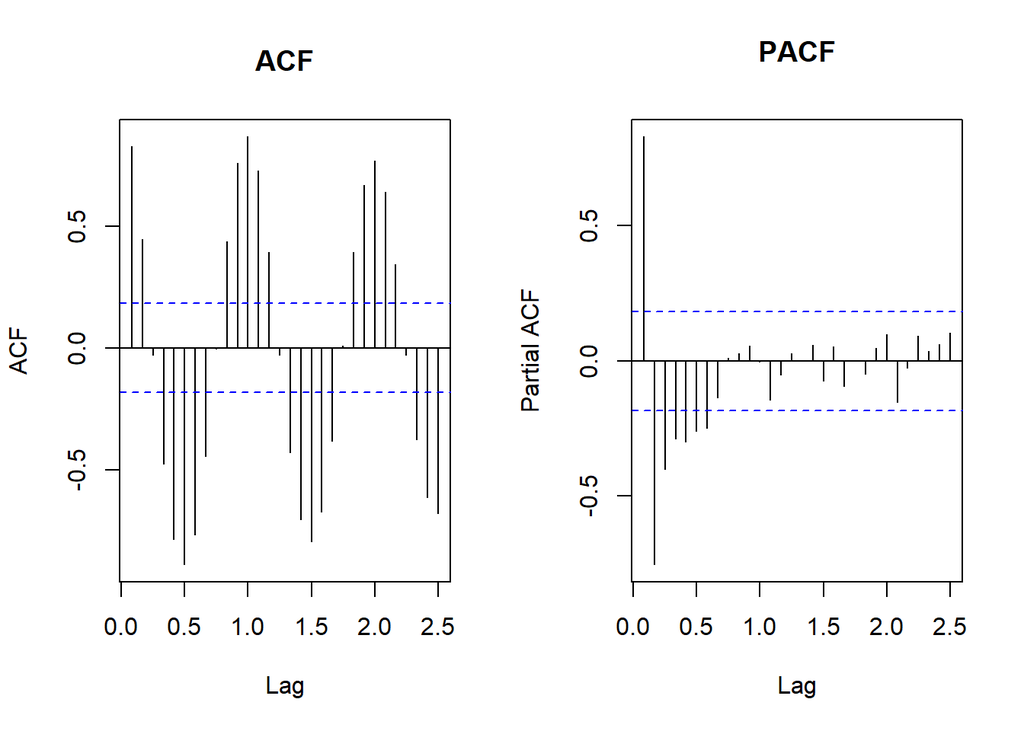

```r
par(mfrow = c(1,2))
acf(dt7.latih.ts, main="ACF", lag.max=30) #ARIMA(0,0,2)
pacf(dt7.latih.ts, main="PACF", lag.max=30) #ARIMA(1,0,0)
```

### Plot EACF

```r
eacf(dt7.latih.ts)
```

```
## AR/MA
##   0 1 2 3 4 5 6 7 8 9 10 11 12 13
## 0 x x o x x x x x o x x  x  x  x
## 1 x x o x x x x x o x x  x  x  x
## 2 x o o o o o o o o o o  o  o  o
## 3 x o o o o o o o o o o  o  o  o
## 4 x x x o o o o o o o o  o  o  o
## 5 x x o x o o o o o o o  o  o  o
## 6 x x o x o o o o o o o  o  o  o
## 7 x o o o o o o o o o o  o  o  o
```

identifikasi model menggunakan plot EACF dilakukan dengan melihat ujung segitiga pada pola segitiga nol. Dalam hal ini model tentatif yang terbentuk adalah ARIMA(2,0,1), dan ARIMA (2,0,2)

sehingga model tentafifnya ialah ARIMA(0,0,2) ARIMA(1,0,0), ARIMA(2,0,1), ARIMA(2,0,2)

# Pendugaan Parameter

### ARIMA (0,0,2)

```r
model1=Arima(dt7.latih.ts, order=c(0,0,2),method="ML")
summary(model1) #AIC=553.54
```

```
## Series: dt7.latih.ts
## ARIMA(0,0,2) with non-zero mean
##
## Coefficients:
##          ma1     ma2     mean
##       1.1984  0.6914  31.5312
## s.e.  0.0665  0.0577   0.6875
##
## sigma^2 = 6.787:  log likelihood = -272.77
## AIC=553.54   AICc=553.91   BIC=564.52
##
## Training set error measures:
##                      ME     RMSE      MAE       MPE     MAPE     MASE      ACF1
## Training set 0.02247843 2.571006 2.079025 -1.119488 6.972736 2.042342 0.3192234
```

```r
lmtest::coeftest(model1) #signifikan
```

```
##
## z test of coefficients:
##
##            Estimate Std. Error z value  Pr(>|z|)
## ma1        1.198377   0.066451  18.034 < 2.2e-16 ***
## ma2        0.691353   0.057705  11.981 < 2.2e-16 ***
## intercept 31.531201   0.687488  45.864 < 2.2e-16 ***
## ---
## Signif. codes:  0 '***' 0.001 '**' 0.01 '*' 0.05 '.' 0.1 ' ' 1
```

### ARIMA (1,0,0)

```r
model2=Arima(dt7.latih.ts, order=c(1,0,0),method="ML")
summary(model2) #AIC=588.74
```

```
## Series: dt7.latih.ts
## ARIMA(1,0,0) with non-zero mean
##
## Coefficients:
##          ar1     mean
##       0.8422  31.4924
## s.e.  0.0501   1.7138
##
## sigma^2 = 9.358:  log likelihood = -291.37
## AIC=588.74   AICc=588.95   BIC=596.97
##
## Training set error measures:
##                      ME     RMSE      MAE        MPE     MAPE     MASE
## Training set 0.08376963 3.032317 2.581975 -0.7611394 8.709099 2.536418
##                   ACF1
## Training set 0.6576075
```

```r
lmtest::coeftest(model2) #signifikan
```

```
##
## z test of coefficients:
##
##            Estimate Std. Error z value  Pr(>|z|)
## ar1        0.842162   0.050136  16.798 < 2.2e-16 ***
## intercept 31.492416   1.713837  18.375 < 2.2e-16 ***
## ---
## Signif. codes:  0 '***' 0.001 '**' 0.01 '*' 0.05 '.' 0.1 ' ' 1
```

### ARIMA (2,0,1)

```r
model3=Arima(dt7.latih.ts, order=c(2,0,1),method="ML")
summary(model3) #AIC=417.39
```

```
## Series: dt7.latih.ts
## ARIMA(2,0,1) with non-zero mean
##
## Coefficients:
##          ar1      ar2      ma1     mean
##       1.7012  -0.9655  -0.8271  31.5364
## s.e.  0.0209   0.0196   0.0407   0.0894
##
## sigma^2 = 2.004:  log likelihood = -203.7
## AIC=417.39   AICc=417.94   BIC=431.12
##
## Training set error measures:
##                        ME     RMSE      MAE        MPE     MAPE     MASE
## Training set 0.0005157665 1.390742 1.114948 -0.2201624 3.701369 1.095276
##                    ACF1
## Training set -0.1353759
```

```r
lmtest::coeftest(model3) #Signifikan
```

```
##
## z test of coefficients:
##
##            Estimate Std. Error z value  Pr(>|z|)
## ar1        1.701172   0.020915  81.336 < 2.2e-16 ***
## ar2       -0.965524   0.019599 -49.264 < 2.2e-16 ***
## ma1       -0.827082   0.040732 -20.305 < 2.2e-16 ***
## intercept 31.536429   0.089392 352.787 < 2.2e-16 ***
## ---
## Signif. codes:  0 '***' 0.001 '**' 0.01 '*' 0.05 '.' 0.1 ' ' 1
```

### ARIMA (2,0,2)

```r
model4=Arima(dt7.latih.ts, order=c(2,0,2),method="ML")
summary(model4) #AIC=412.44
```

```
## Series: dt7.latih.ts
## ARIMA(2,0,2) with non-zero mean
##
## Coefficients:
##          ar1      ar2      ma1     ma2     mean
##       1.7212  -0.9864  -1.1737  0.3444  31.5369
## s.e.  0.0975   0.1039   2.2700  2.3145   0.0847
##
## sigma^2 = 1.892:  log likelihood = -200.22
## AIC=412.44   AICc=413.21   BIC=428.91
##
## Training set error measures:
##                        ME    RMSE      MAE        MPE     MAPE     MASE
## Training set -0.001148506 1.34529 1.079332 -0.2250118 3.555292 1.060288
##                    ACF1
## Training set 0.07963623
```

```r
lmtest::coeftest(model4) #tidak signifikan
```

```
##
## z test of coefficients:
##
##            Estimate Std. Error  z value Pr(>|z|)
## ar1        1.721207   0.097454  17.6618   <2e-16 ***
## ar2       -0.986391   0.103940  -9.4900   <2e-16 ***
## ma1       -1.173720   2.270001  -0.5171   0.6051
## ma2        0.344402   2.314457   0.1488   0.8817
## intercept 31.536897   0.084699 372.3404   <2e-16 ***
## ---
## Signif. codes:  0 '***' 0.001 '**' 0.01 '*' 0.05 '.' 0.1 ' ' 1
```

Penduga terbaik ialah aic terkecil dan parameter signifikan yang terdapat di ARIMA(2,0,1)

# analisis sisaan

### Eksplorasi

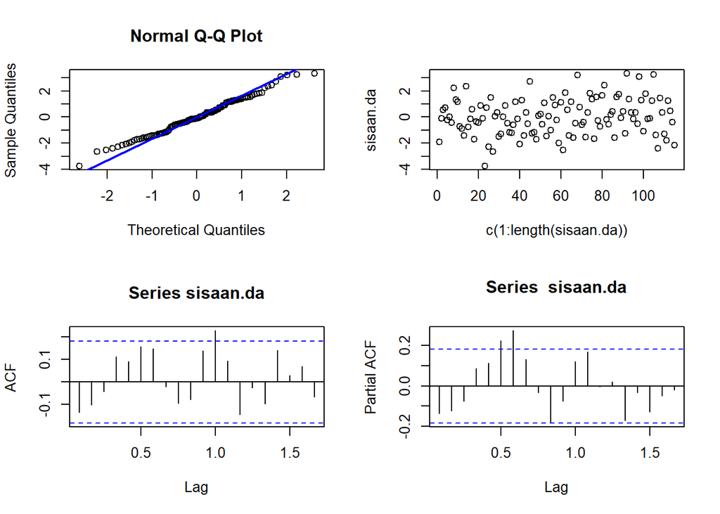

```r
#Eksplorasi
sisaan.da <- model3$residuals
par(mfrow=c(2,2))
qqnorm(sisaan.da)
qqline(sisaan.da, col = "blue", lwd = 2)
plot(c(1:length(sisaan.da)),sisaan.da)
acf(sisaan.da)
pacf(sisaan.da)
```

```r
par(mfrow = c(1,1))
```

### Uji Formal

```r
#1) Sisaan Menyebar Normal
ks.test(sisaan.da,"pnorm")
```

```
##
##  Asymptotic one-sample Kolmogorov-Smirnov test
##
## data:  sisaan.da
## D = 0.1315, p-value = 0.03747
## alternative hypothesis: two-sided
```

$H_0$ : Sisaan menyebar normal

$H_1$ : Sisaan tidak menyebar normal

Berdasarkan uji KS tersebut, didapat *p-value* sebesar 0.03747 yang kurang dari taraf nyata 5% sehingga tolak $H_0$ dan menandakan bahwa sisaan tidak menyebar normal. Hal ini sesuai dengan hasil eksplorasi menggunakan plot kuantil-kuantil normal.

```r
#2) Sisaan saling bebas/tidak ada autokorelasi
Box.test(sisaan.da, type = "Ljung")
```

```
##
##  Box-Ljung test
##
## data:  sisaan.da
## X-squared = 2.163, df = 1, p-value = 0.1414
```

$H_0$ : Sisaan saling bebas

$H_1$ : Sisaan tidak tidak saling bebas

Berdasarkan uji Ljung-Box tersebut, didapat *p-value* sebesar 0.1414 yang lebih besar dari taraf nyata 5% sehingga tak tolak $H_0$ dan menandakan bahwa sisaan saling bebas. Artinya tidak ada autokorelasi

```r
#3) Sisaan homogen
Box.test((sisaan.da)^2, type = "Ljung")
```

```
##
##  Box-Ljung test
##
## data:  (sisaan.da)^2
## X-squared = 0.93889, df = 1, p-value = 0.3326
```

$H_0$ : Ragam sisaan homogen

$H_1$ : Ragam sisaan tidak homogen

Berdasarkan uji Ljung-Box tersebut. didapat *p-value* sebesar 0.3326 yang lebih besar dari taraf nyata 5% sehingga tak tolak $H_0$ dan menandakan bahwa ragam sisaan homogen

```r
#4) Nilai tengah sisaan sama dengan nol
t.test(sisaan.da, mu = 0, conf.level = 0.95)  #tak tolak h0 > nilai tengah sisaan sama dengan 0
```

```
##
##  One Sample t-test
##
## data:  sisaan.da
## t = 0.0039597, df = 114, p-value = 0.9968
## alternative hypothesis: true mean is not equal to 0
## 95 percent confidence interval:
##  -0.2575183  0.2585498
## sample estimates:
##    mean of x
## 0.0005157665
```

$H_0$ : nilai tengah sisaan sama dengan 0

$H_1$ : nilai tengah sisaan tidak sama dengan 0

Berdasarkan uji-ttersebut, didapat *p-value* sebesar 0.9968 yang lebih besar dari taraf nyata 5% sehingga tak tolak $H_0$ dan menandakan bahwa nilai tengah sisaan sama dengan 0

# Overfitting

### ARIMA(3,0,1)

```r
model5=Arima(dt7.latih.ts, order=c(3,0,1),method="ML")
summary(model5) #AIC=416.65
```

```
## Series: dt7.latih.ts
## ARIMA(3,0,1) with non-zero mean
##
## Coefficients:
##          ar1      ar2      ar3     ma1     mean
##       1.5331  -0.6732  -0.1717  -0.794  31.5359
## s.e.  0.1013   0.1737   0.1013   0.049   0.0884
##
## sigma^2 = 1.971:  log likelihood = -202.32
## AIC=416.65   AICc=417.43   BIC=433.12
##
## Training set error measures:
##                        ME     RMSE      MAE        MPE     MAPE     MASE
## Training set 0.0006203924 1.373129 1.103212 -0.2164433 3.648832 1.083747
##                     ACF1
## Training set -0.03455449
```

```r
lmtest::coeftest(model5) #Tidak signifikan
```

```
##
## z test of coefficients:
##
##            Estimate Std. Error  z value  Pr(>|z|)
## ar1        1.533075   0.101326  15.1301 < 2.2e-16 ***
## ar2       -0.673243   0.173708  -3.8757 0.0001063 ***
## ar3       -0.171749   0.101340  -1.6948 0.0901188 .
## ma1       -0.794045   0.049000 -16.2051 < 2.2e-16 ***
## intercept 31.535896   0.088448 356.5475 < 2.2e-16 ***
## ---
## Signif. codes:  0 '***' 0.001 '**' 0.01 '*' 0.05 '.' 0.1 ' ' 1
```

berdasarkan hasil overfitting yg terbaik tetap model ARIMA(2,0,1)

# Peramalan

```r
#---FORECAST---#
ramalan <- forecast::forecast(model3, h = 29)
ramalan
```

```
##        Point Forecast    Lo 80    Hi 80    Lo 95    Hi 95
## Aug 10       36.88431 35.07017 38.69845 34.10983 39.65880
## Sep 10       34.62509 32.21561 37.03457 30.94011 38.31007
## Oct 10       31.62727 29.03874 34.21580 27.66845 35.58608
## Nov 10       28.70878 26.11907 31.29850 24.74816 32.66941
## Dec 10       26.63841 23.93371 29.34312 22.50192 30.77491
## Jan 11       25.93422 22.88731 28.98113 21.27438 30.59406
## Feb 11       26.73526 23.27822 30.19230 21.44818 32.02235
## Mar 11       28.77788 25.03910 32.51667 23.05990 34.49586
## Apr 11       31.47931 27.64615 35.31246 25.61701 37.34161
## May 11       34.10270 30.26902 37.93637 28.23960 39.96580
## Jun 11       35.95725 32.05864 39.85585 29.99484 41.91965
## Jul 11       36.57920 32.48004 40.67837 30.31007 42.84833
## Aug 11       35.84665 31.49176 40.20154 29.18642 42.50688
## Sep 11       33.99994 29.46126 38.53862 27.05863 40.94126
## Oct 11       31.56566 26.96457 36.16676 24.52889 38.60243
## Nov 11       29.20758 24.60621 33.80896 22.17039 36.24478
## Dec 11       27.54644 22.90030 32.19258 20.44078 34.65210
## Jan 12       26.99732 22.21258 31.78206 19.67970 34.31495
## Feb 12       27.66706 22.70260 32.63152 20.07458 35.25954
## Mar 12       29.33658 24.24113 34.43203 21.54376 37.12940
## Apr 12       31.53008 26.39014 36.67002 23.66922 39.39094
## May 12       33.64963 28.50954 38.78972 25.78854 41.51072
## Jun 12       35.13748 29.96430 40.31066 27.22578 43.04918
## Jul 12       35.62209 30.34697 40.89721 27.55449 43.68969
## Aug 12       35.00994 29.60190 40.41797 26.73906 43.28081
## Sep 12       33.50066 27.99529 39.00604 25.08092 41.92041
## Oct 12       31.52417 25.98589 37.06246 23.05410 39.99425
## Nov 12       29.61907 24.08070 35.15743 21.14887 38.08927
## Dec 12       28.28650 22.72280 33.85020 19.77755 36.79545
```

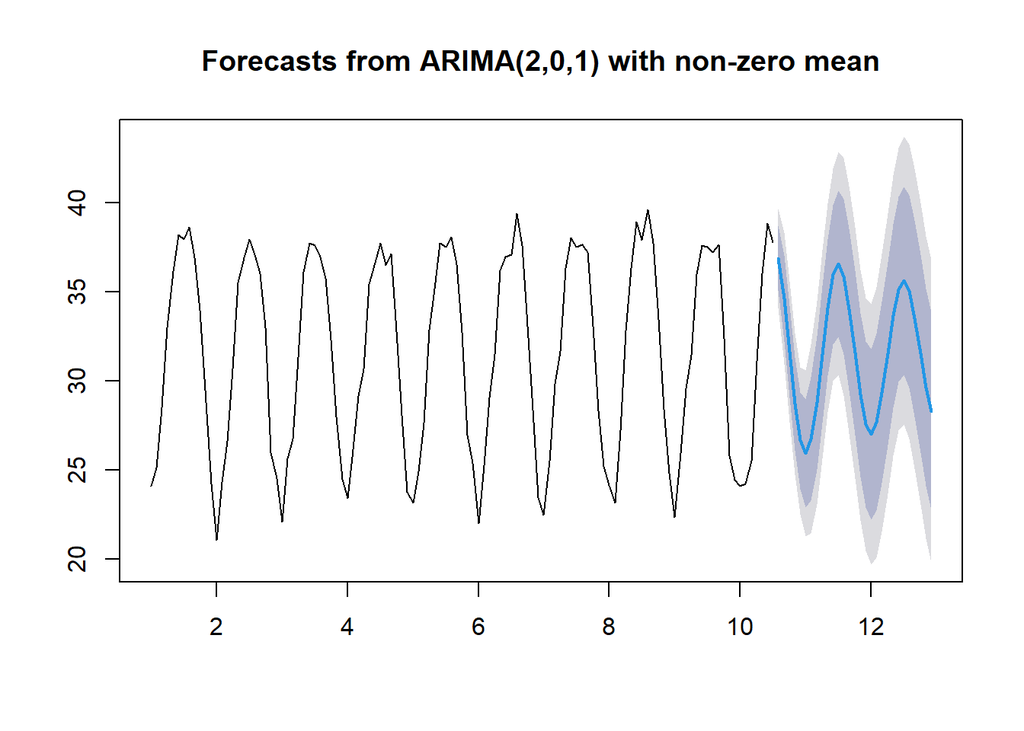

```r
data.ramalan <- ramalan$mean
plot(ramalan)
```

# AKURASI

```r
perbandingan <- matrix(data=c(dt7.uji.ts, data.ramalan),
                     nrow = length(dt7.uji.ts), ncol = 2)
colnames(perbandingan) <- c("Aktual","Hasil Forecast")
perbandingan
```

```
##       Aktual Hasil Forecast
##  [1,]  37.38       36.88431
##  [2,]  37.95       34.62509
##  [3,]  33.18       31.62727
##  [4,]  29.15       28.70878
##  [5,]  25.00       26.63841
##  [6,]  20.65       25.93422
##  [7,]  23.82       26.73526
##  [8,]  26.99       28.77788
##  [9,]  30.51       31.47931
## [10,]  35.40       34.10270
## [11,]  37.91       35.95725
## [12,]  36.65       36.57920
## [13,]  35.96       35.84665
## [14,]  37.19       33.99994
## [15,]  32.49       31.56566
## [16,]  28.18       29.20758
## [17,]  24.94       27.54644
## [18,]  23.19       26.99732
## [19,]  22.96       27.66706
## [20,]  28.90       29.33658
## [21,]  31.41       31.53008
## [22,]  34.97       33.64963
## [23,]  39.55       35.13748
## [24,]  37.24       35.62209
## [25,]  38.26       35.00994
## [26,]  36.96       33.50066
## [27,]  34.19       31.52417
## [28,]  28.90       29.61907
## [29,]  25.01       28.28650
```

```r
accuracy(data.ramalan[1:29], head(dt7.uji.ts,n=length(dt7.uji.ts)))
```

```
##                 ME     RMSE      MAE      MPE    MAPE      ACF1 Theil's U
## Test set 0.0273604 2.512867 2.047754 -1.40432 7.05646 0.6175055 0.7687588
```